# FI Dynamics Vignette

Dec 2024 Glen Pridham

instructions and sample code for fitting model

please see https://arxiv.org/abs/2412.07795 for more info and citation info

summary: fits damage, repair and mortality probabilities to longitudinal binary deficit data data needed are: 1. binary data stored in a data.frame. you need some number, p, of binary deficits measured now and the same number, p, measured at some followup time. the followup must be %s_next where %s is the original name. binary data are size (N x times) individual measurement rows and 2*p variable columns -note: if you have > 2 timepoints, stack them. e.g. if I measure Bob 4 times I should have 3 rows for him: 1st measurement with 2nd measurement followup, 2nd measurement with 3rd measurement followup, and 3rd measurement with 4th measurement followup.

optional data but must be entered: 1. survival data marking an end to the individual’s observations. if you have no survival data you must enter the final observation times as a survival object. survival data are Surv() objects of size N individual rows and 3 columns (start, stop and status; set start = 0 if not provided)

what the script does: 1. fits the model, bootstraps and saves the output 2. generates diagnostic plots 3. generates a synthetic population via simulation

packages needed: 1. survival 2. ggplot2 (for plots, you may be able to avoid this by setting skipPlots=T in DiagnoseModel.exp)

recommended packages: 1. metr (for nullcline plot) 2. ggridges (for ridge plots) 3. mgcv (for crossing statistic)

#step 1. load in functions set directory where .R file is and where you want to save/load from

```r
gRootName = "fi_dynamics"
gOutputDir = "C:/Users/Glen/OneDrive - Dalhousie University/analysis/fi_dynamics" #enter analysis directory here
gDataDir = "C:/Users/Glen/OneDrive - Dalhousie University/analysis/fi_dynamics/data" #where you want to save/load from

source(sprintf("%s/fi_dynamics_github.R",gOutputDir),verbose=0)
library(metR)
```

#step 2. load in data the model requires longitudinal (measurement and followup) binary data and survival data (this can be faked) for example, generate some artificial data

```r
N = 1000
p = 30 #number of deficits
age = rnorm(N,70,5)
dt = 1 #followup time

baseline = matrix(NA,nrow=N,ncol=p)
colnames(baseline)=sprintf("b%02d",1:ncol(baseline))
followup = matrix(NA,nrow=N,ncol=p)
colnames(followup)=sprintf("%s_next",colnames(baseline)) #NOTE: you MUST name the followup the same as baseline but with _next
#randomly generate baseline:
for (j in 1:ncol(baseline)) baseline[,j] = sample(c(0,1),N,T,prob=c(.8,.2))
#generate followup assuming a simple model (roughly approximates the values we got in the paper but exaggerated a bit)
#damage rate = exp( -6 + 3.5*fi + 2.5*age/100)
#repair rate = exp( -1 - 0.6*fi - age/100)
#approximate prob = rate * dt
#fi = mean( baseline )
fi = apply(baseline,1,mean,na.rm=T)
for (j in 1:ncol(followup))
{
  #carry forward previous value
  followup[,j] = baseline[,j]

  #randomly repair:
  damaged = baseline[,j] == 1
  followup[damaged,j] = 1 - as.integer(runif(sum(damaged),0,1) <= exp(-1 - 0.6*fi[damaged] - age[damaged]/100))*dt
  #randomly damage:
  repaired = baseline[,j] == 0
  followup[repaired,j] = as.integer(runif(sum(repaired),0,1) <=  exp(-4 + 3.5*fi[repaired] + 2.5*age[repaired]/100))*dt
}
```

illustrate the effect of the FI

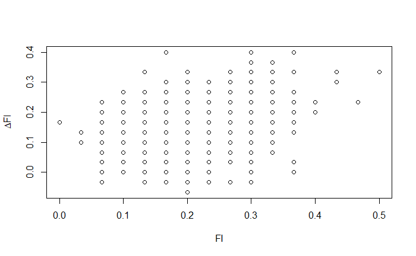

```r
fi_baseline = apply(baseline,1,mean)
fi_followup = apply(followup,1,mean)
plot(fi_baseline,fi_followup-fi_baseline,xlab="FI",ylab=bquote(Delta*"FI"))
```

we also need survival for simplicity let’s just assume everybody is censored at the end of the study

```r
s = Surv(age,age+dt,event=rep(0,N))
```

prep the data we need baseline and followup, a unique ID column, as well as age and an indicator variable for when the last measurement was

```r
data = data.frame(baseline,followup)
data[,"id"] = 1:nrow(data) #used for trajectories
data[,"age"] = age
data[,"age_next"] = age + dt
data[,"last_measurement"] = T #only 1 followup so everybody true
```

#step 3. fit Model now fit a model to the data this function will bootstrap fit

```r
#the first 5 are needed, the rest are options to show you
m = DiagnoseModel.exp(data = data,
                      fiVar=colnames(baseline),
                      s=s,
                      dt=dt,
                      GenBasis=GenBasisDefault, #you can have any basis function of the FI here
                      nboot=10, #number of bootstraps to perform (default: 100)
                      save=F, #you can optionally save and load
                      load=F,
                      file=sprintf("%s/sim_fi_dynamics.rds",gDataDir), #where to look to load and where to save (will overwrite)
                      skipPlots=F, #if you don't want plots / don't have the libraries you can skip this (it can also be slow)
                      verbose=T, #prints lots of info, can be spammy
                      simMultiplier=1 #larger = higher precision, slower simulation (default: 10)
                      )
```

```
[1] 2
[1] "starting guesses:"
 [1] -1.512153  0.000000  0.000000  0.000000 -1.763621  0.000000  0.000000  0.000000 -4.610588  0.000000  0.000000  0.000000
[1] "starting ll:"
[1] -19890.56
[1] "starting grad:"
 [1]   508.664847   212.402994   508.664847   212.402994    48.068943     2.619175    48.068943     2.619175   990.054032   194.578619
[11] 70755.800574 13894.190135
..........
```

```
[1] "parameter estimate:"
  ln_damage_f^0   ln_damage_f^1 ln_damage_f^0*t ln_damage_f^1*t   ln_repair_f^0   ln_repair_f^1 ln_repair_f^0*t ln_repair_f^1*t
   -4.018520973     2.209427053     0.024056609     0.034314902    -0.685690257    -3.901556587    -0.009460662     0.032895272
  ln_hazard_f^0   ln_hazard_f^1 ln_hazard_f^0*t ln_hazard_f^1*t
   -1.661443939     0.793472450     0.023407362    -0.010434194
[1] "Done bootstraps, starting sim..."
[1] "Done simulations"
```

#step 4. inspect results the estimated parameter values are stored in a matrix where each row is a different bootstrap since we had no survival the hazard estimates will be nonsense, only that the baseline hazard has to be relatively small

Here I compare the estimates to the known values to see they’re sane.

```r
par = apply(m$par,2,mean)
se = apply(m$par,2,sd)

#compare to ground truth from sim
#damage rate = exp( -6 + 3.5*fi + 2.5*age/100)
#repair rate = exp( -1 - 0.6*fi - age/100)
gt = c(-6,3.5,2.5/100,0,-1,-.6,-1/100,0,-1,0,0,0)

plot(gt[1:4],par[1:4],main="Damage parameters",xlab="Ground truth",ylab="Estimate",ylim=range(c(gt[1:4],par[1:4])))
arrows(gt[1:4],par[1:4]-se[1:4],gt[1:4],par[1:4]+se[1:4], angle = 90, code = 3, length = 0.001)
```

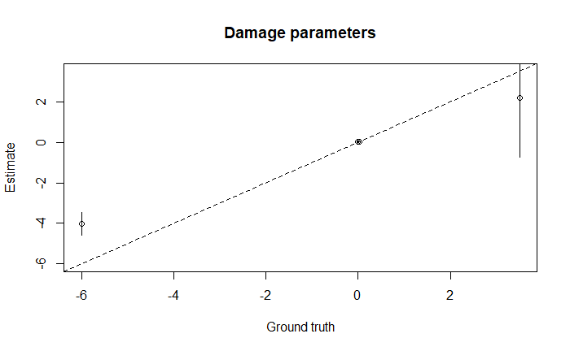

```r
abline(0,1,lty=2)
```

```r
plot(gt[1:4+4],par[1:4+4],main="Repair parameters",xlab="Ground truth",ylab="Estimate",ylim=range(c(gt[1:4+4],par[1:4+4])))
arrows(gt[1:4+4],par[1:4+4]-se[1:4+4],gt[1:4+4],par[1:4+4]+se[1:4+4], angle = 90, code = 3, length = 0.001)
```

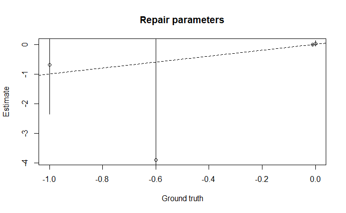

```r
abline(0,1,lty=2)
```

```r
plot(gt[1:4+8],par[1:4+8],main="Hazard parameters",xlab="Ground truth",ylab="Estimate",ylim=range(c(gt[1:4+8],par[1:4+8])))
arrows(gt[1:4+8],par[1:4+8]-se[1:4+8],gt[1:4+8],par[1:4+8]+se[1:4+8], angle = 90, code = 3, length = 0.001)
```

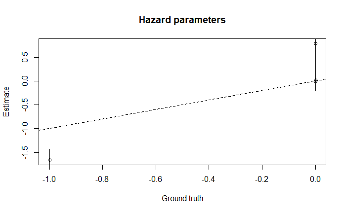

```r
abline(0,1,lty=2)
```

```r
for (i in 1:length(m$plots$key))
{
  m$plots$key[[i]]
}
```